# Lab1

STA 206 | Fall 2021

September 27, 2021

## What is R?

For now, we will learn to use R as a fancy calculator. There are a lot of formulas in this class that would be tedious to do by hand or with a simple calculator. For instance, calculating the sample mean of a list of 100 numbers would take a while to do by hand, but seconds in R. Another convenient feature of R is its plotting capabilities. Using R one can produce clean looking plots very effciently. Later, we will learn how to use various built in functions (such as *lm*) in R to perform data analysis.

## Installation

- Installing *R*
  - Go to https://www.r-project.org/.
  - On the left side of the page, click the “CRAN” link.
  - Scroll down to the USA section, and click a link (say, Duke).
  - Click the download link for your operating system (Windows, Mac, or Linux).
  - Follow the instructions to download the latest version of R.
- Installing *RStudio*
  - An integrated development environment for R
  - Go to https://rstudio.com/products/rstudio/download/ and follow the instructions.

## Using R

Getting help about any in-built function/package:

```r
#details about the 'lm' function
?lm # help(lm)
```

Check and set working directory :

```r
getwd()
?setwd
```

Check R version:

```r
version
```

```
##                _
## platform       x86_64-w64-mingw32
## arch           x86_64
## os             mingw32
## system         x86_64, mingw32
## status
## major          4
## minor          0.2
## year           2020
## month          06
## day            22
## svn rev        78730
## language       R
## version.string R version 4.0.2 (2020-06-22)
## nickname       Taking Off Again
```

### Assignment and arithmetic

Assignment of variables means that in R you can create your own variables, vectors, matrices, etc. R can perform basic arithmetic operations with numbers or declared variables. Here are some examples:

```r
#define variables x and y
x = 4
y = 3

#perform arithmetic on variables as well as numbers
x * y - 4
```

```
## [1] 8
```

R can perform arithmetic on numbers, but it is really designed to work with vectors. Vectors are just lists of numbers, and in R we can define and perform operations on them. To create a vector, we use the concatenate function c():

```r
#use concatenate function to make a vector called 'myvec'
myvec = c(4,5,6)
#display myvec
myvec
```

```
## [1] 4 5 6
```

Once we have a vector, we can perform arithmetic on the entire vector at once. We can also add two vectors together.

```r
#perform arithmetic on entire vectors at once
myvec + 3
```

```
## [1] 7 8 9
```

```r
myvec * 2
```

```
## [1]  8 10 12
```

```r
#create another vector called 'myvec2'
myvec2 = c(1,2,1)
#add my vectors together
myvec + myvec2
```

```
## [1] 5 7 7
```

There are built in functions that we can perform on a vector as well.

```r
#find the number of elements in a vector
length(myvec)
```

```
## [1] 3
```

```r
#sum the elements of a vector
sum(myvec)
```

```
## [1] 15
```

```r
#take the product of all elements of a vector
prod(myvec)
```

```
## [1] 120
```

```r
#calculate the sample mean of a vector
mean(myvec)
```

```
## [1] 5
```

```r
#calculate the median of a vector
median(myvec)
```

```
## [1] 5
```

```r
#calculate the sample standard deviation of a vector
sd(myvec)
```

```
## [1] 1
```

```r
#vector of numbers 1 to 10
myvec3 = 1:10
```

### Exercise:

Create two vectors, one with any 5 numbers and the other with numbers 12 to 18. Merge them in a single vector and find the number of elements of the new vector, its mean and standard deviation.

## Consider a toy example:

```r
#define vectors X and Y
X = c(1.86,.22,3.55,3.29,1.25)
Y = c(3.34,1.79,5.66,5.83,4.74)

#Xbar is the sample mean of X
Xbar = mean(X)
Xbar
```

```
## [1] 2.034
```

```r
#similarly for Y
Ybar = mean(Y)
Ybar
```

```
## [1] 4.272
```

```r
#more advanced calculations (^ means exponent)
den = sum((X - Xbar)^2)

num = sum((X - Xbar)*(Y - Ybar))
```

Here we have everything calculated, so we can easily obtain

$\hat{\beta}_1 = \frac{\sum_{i=1}^n (X_i - \bar{X})(Y_i - \bar{Y})}{\sum_{i=1}^n (X_i - \bar{X})^2} = \frac{ 8.35866 }{ 7.81132 } = 1.07$, and $\hat{\beta}_0 = \bar{Y} - \hat{\beta}_1 \bar{X} = 4.272 - 1.07(2.034) = 2.1$.

```r
beta1 = num/den
beta0 = Ybar - beta1*Xbar
```

We can now use this to find the fitted values $\hat{Y}_i$ and residuals $e_i$:

```r
### fitted values
Yhat = beta0 + beta1*X
Yhat
```

```
## [1] 4.085808 2.330893 5.894226 5.616008 3.433065
```

```r
## residuals
e=Y-Yhat
e
```

```
## [1] -0.7458078 -0.5408928 -0.2342263  0.2139920  1.3069350
```

```r
### check properties of residuals:
sum(e)
```

```
## [1] -8.881784e-16
```

```r
sum(X*e)
```

```
## [1] -8.743006e-16
```

```r
sum(Yhat*e)
```

```
## [1] -2.88658e-15
```

## Plotting

Now that we have our data, and the fitted regression line, we would like to plot them both to see what we have done. The plot function in R is fairly simple. There are several options one can use when plotting, but we start with the basic ones:

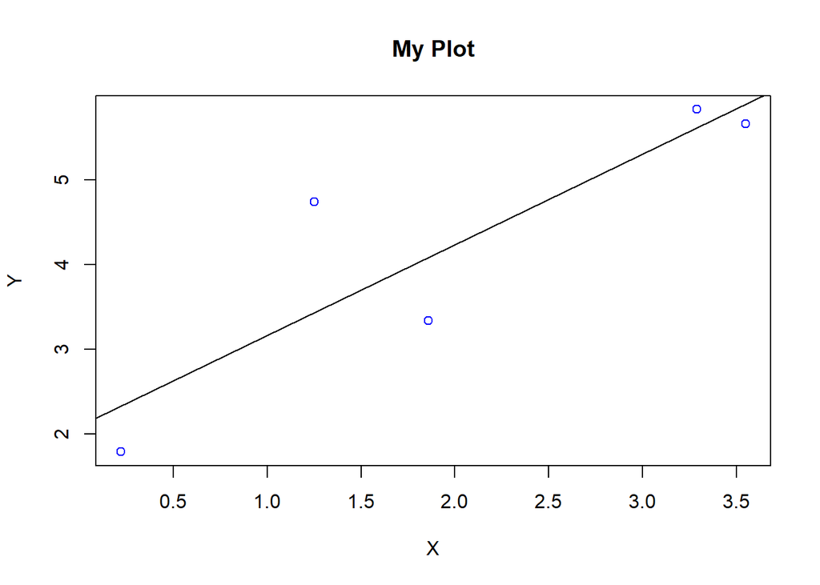

```r
#main is the title of the plot, col is the color of the points
plot(X,Y,main='My Plot',col='blue')

#Use ?plot for more details about different parameters

#use abline to meake a line
abline(beta0,beta1)
```

Here, the function abline() creates a line with a given slope and intercept.

We can also show separate plots in one window by use of the par command:

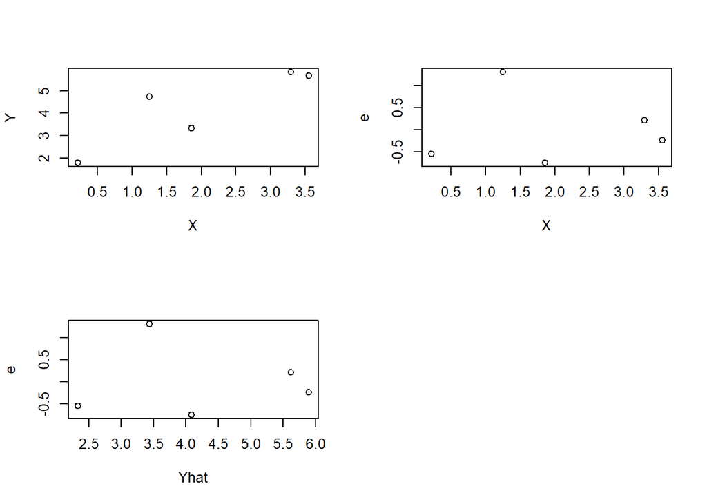

```r
par(mfrow=c(2,2)) # arrange plots in 2x2 matrix
plot(X, Y)
plot(X, e)
plot(Yhat, e)

par(mfrow=c(1,1))
```

## Overlaying plots and adding legend

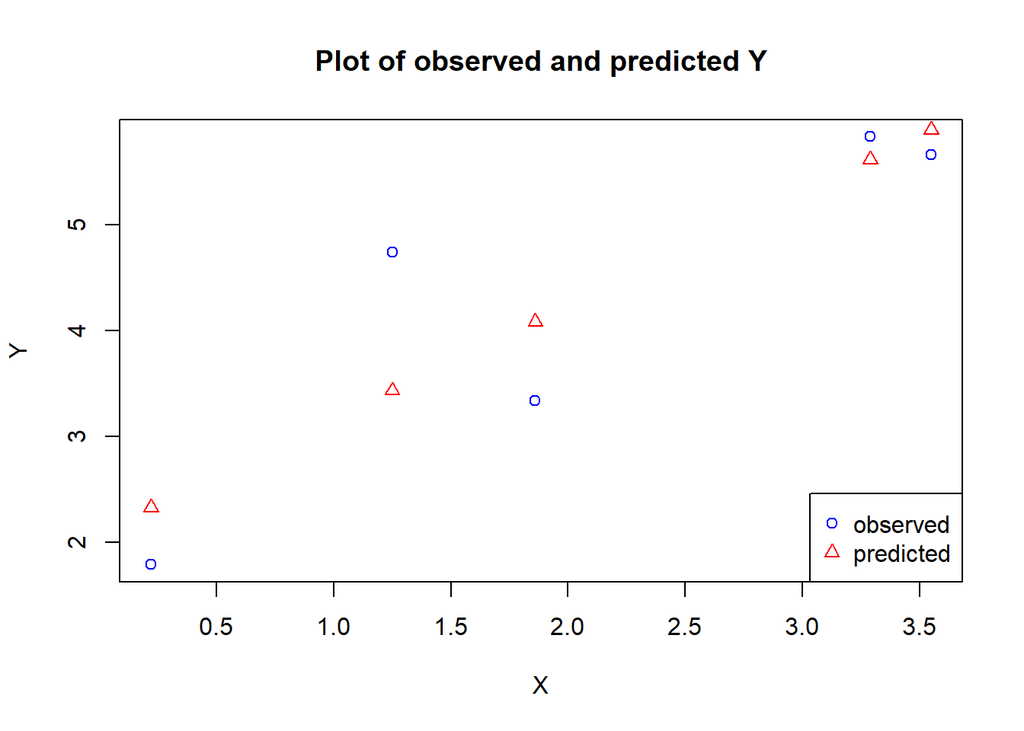

```r
plot(X,Y, main='Plot of observed and predicted Y',col='blue')
points(X, Yhat, col = 'red', pch = 2)
legend("bottomright", legend = c("observed", "predicted"), col = c("blue", "red"),
       pch = c(1,2))
```

### Exercise:

Data is given for heights and weights of males and females. Plot height versus weight for men and women using different colored symbols in the same graph and add legend.

```r
w_f = c(130,127, 141, 160, 135, 119)##female height
h_f = c(153, 168, 152, 173, 166, 151)##female weight

w_m = c(149, 154, 171, 163, 160, 136)##male height
h_m = c(162, 175, 180, 171, 169, 158)##male weight
```

Another example:

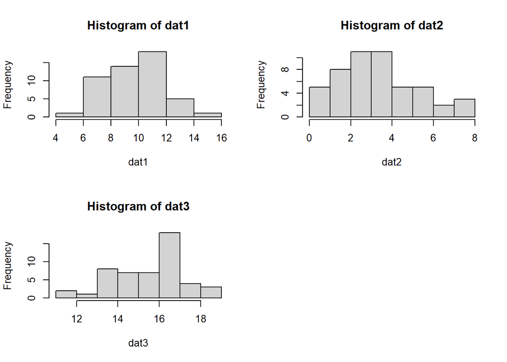

```r
dat1 = rbinom(50, size =  20, prob = 0.5)
dat2 = rbinom(50, size =  20, prob = 0.2)
dat3 = rbinom(50, size =  20, prob = 0.8)

par(mfrow=c(2,2)) # arrange plots in 2x2 matrix
hist(dat1)
hist(dat2)
hist(dat3)

par(mfrow = c(1,1))
```

We can further improve the plot by adjusting the default margin settings:

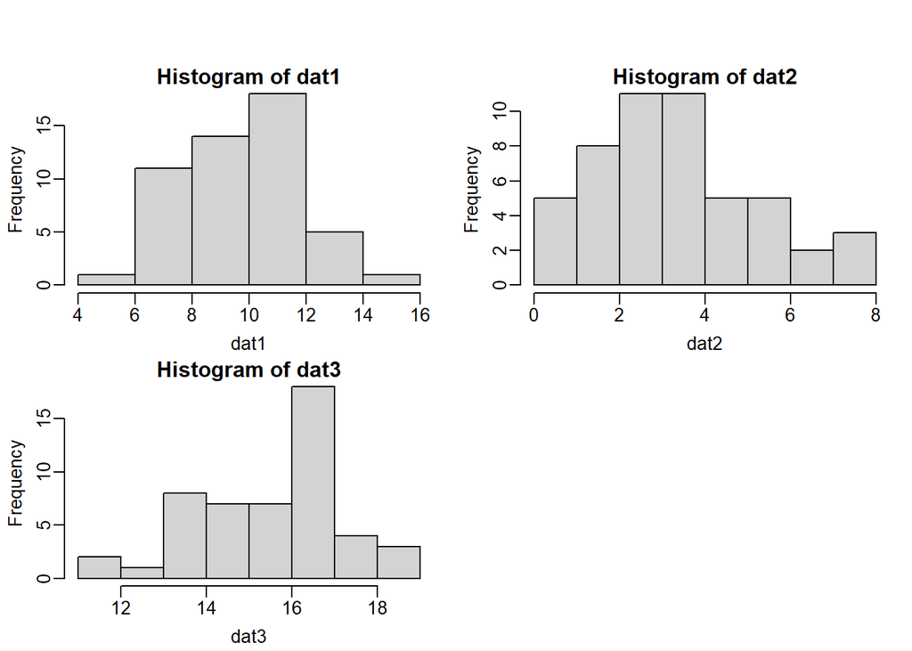

```r
#help(par)
par(mfrow=c(2,2),mgp=c(1.8,.5,0), mar=c(3,3,1,1), oma=c(0,0,3,0), pty='m') # mar sets the margin sizes, mgp sets the axis label locations, oma for outer margins
hist(dat1)
hist(dat2)
hist(dat3)
```

## Inference

A bottle filling machine is set to fill bottles with soft drink to a volume of 500 ml. The actual volume is assumed to follow a normal distribution. The manufacturer believes the machine is **under-filling** bottles. A sample of 20 bottles is taken and the volume of liquid inside is measured.

Let’s begin by loading the dataset (bottles.csv) into R. We can do this by the *read.table* command:

```r
path="" ##put data path here; use the empty string if data is under the R working directory
#bottles = read.table(file=paste(path, "bottles.csv", sep=""),
#header=TRUE)

#bottles = read.table("D:/fall 2020/STA 206/Lab 1/bottles.csv", header = T)

bottles = read.csv("bottles.csv", header = T)

###One can set the working directory and avoid putting the entire path while importing data
```

We can also do this in Rstudio by the “import dataset” GUI. Either way, we should inspect the data after read-in to verify its contents.

```r
head(bottles)
```

```
##   Volume
## 1 484.11
## 2 459.49
## 3 471.38
## 4 512.01
## 5 494.48
## 6 528.63
```

Now we can proceed to performing inference. First, we should check the assumption of normality by an exploratory plot. We get the following histogram:

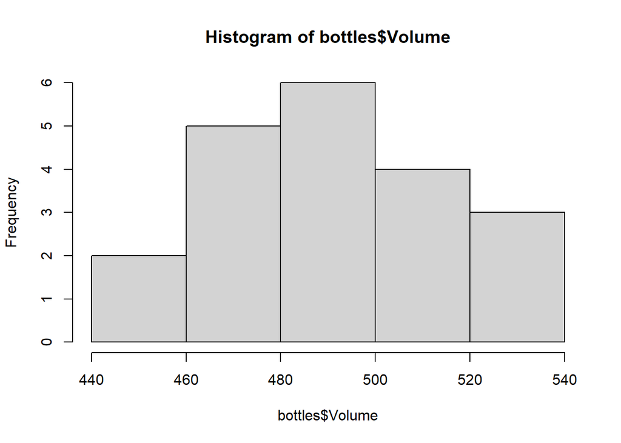

```r
hist(bottles$Volume)
```

We can clearly see that our sample may provide evidence of under-filling and seems to follow a normal distribution.

We can also look into the box-plot and get the summmary of the variable “Volume”:

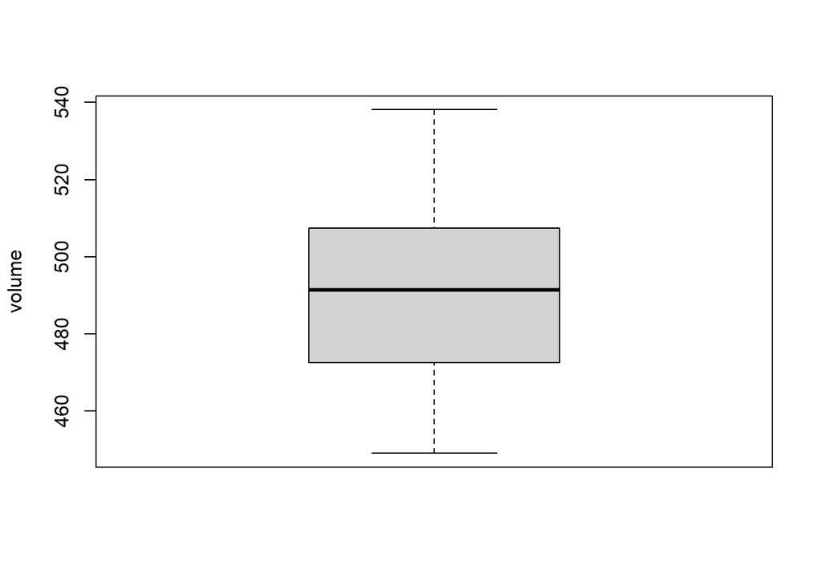

```r
boxplot(bottles$Volume,ylab="volume")
```

```r
summary(bottles$Volume) ##The "$" sign extracts the variable from the data frame
```

```
##    Min. 1st Qu.  Median    Mean 3rd Qu.    Max.
##   449.1   473.3   491.5   491.6   505.1   538.1
```

To test the manufacturer’s suspicion, we consider the following hypothesis test:

$$H_0: \mu =500\: vs \: H_1: \mu < 500$$
We use the following test statistic (learned in elementary statistics):

$$\frac{\bar{X} - 500}{s/\sqrt{20}} \sim t_{(19)} \; under H_0$$
with decision rule: reject $H_0$, at significance level $\alpha$, if

$$\frac{\bar{X} - 500}{s/\sqrt{20}} < t(\alpha;19)$$
or equivalently by use of p-values, reject if

$$P(t_{(19)} < \frac {\bar{X} - 500}{s/\sqrt{20}} ) < \alpha$$

With R, we can quickly carry out this hypothesis test. Let’s test at $\alpha = 0.1$ level of signifiance. Calculating the necessary quantities:

```r
n = length(bottles$Volume)
xbar = mean(bottles$Volume)
shat = sd(bottles$Volume)

# Test Statistic
sqrt(n)*(xbar - 500)/shat
```

```
## [1] -1.520463
```

```r
# Critical value
qt(p=.1, df=n-1)
```

```
## [1] -1.327728
```

```r
# P-value
pt( sqrt(n)*(xbar - 500)/shat, df=n-1 )
```

```
## [1] 0.07243113
```

From both calculations we can see that we can reject the null hypothesis at significance level 0.1. We can see that the lowest level of significance that the null hypothesis can be rejected at is around 0.07. It looks like the manufacturer’s suspicion was correct. Note that the function `qnorm()` gives the percentiles (a.k.a. quantiles) of the standard normal distribution. Sometimes we would like to find the percentiles for a *t distribution* or a *chi-square distribution* or an *F distribution*, these are by the functions `qt()`, `qchisq()`, `qf()`, respectively.

```r
##95% percentile of chi-square distribution with 3 degrees of freedom
qchisq(0.95, 3)
```

```
## [1] 7.814728
```

```r
### 95% percentile of t-distribution with 3 degrees of freedom
qt(0.95, 3)
```

```
## [1] 2.353363
```

```r
## 95% percentile of F-distribution with (1,3) degrees of freedom
qf(0.95, 1,3)
```

```
## [1] 10.12796
```

### Exercise:

Calculate the 0.975 percentile for:

- Standard Normal Distribution
- t-distribution with 10 degrees of freedom
- Chi-square distribution with 10 degrees of freedom
- F-distribution with (1,10) degrees of freedom

## Save workspace or objects

You may want to save your entire workspace or certain objects for future use. You can use `save.image()` and `save()` functions.

```r
save.image() ##save the current workspace
```

```r
xx=1:10
save(xx, file="xx.rda") ##save vector xx to file xx.rda
```

If we only want the output in the document and not the associated code, we put `echo = FALSE`. For example:

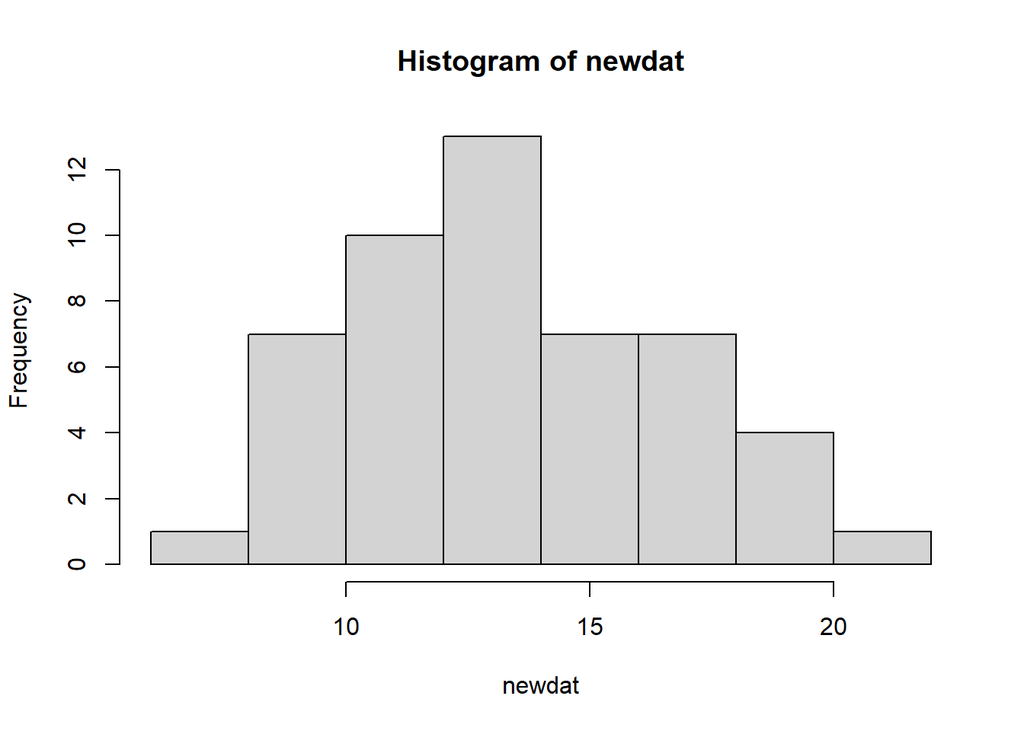

The`echo = FALSE` parameter added to the code chunk prevents printing of the R code that generated the plot.

If we only want the code, but do not want to evaluate the code, we put `eval = FALSE`

```r
newdat = dat1+dat2
hist(newdat)
```

Knitting to html does not require downloading addtional software and is an easy solution to get the report in a concise manner.